# Lab 6

Author

Hanin Almodaweb

### Read in Medical Transcriptions

```r
library(readr)
library(dplyr)
mt_samples <- read_csv("https://raw.githubusercontent.com/USCbiostats/data-science-data/master/00_mtsamples/mtsamples.csv")
mt_samples <- mt_samples |>
  select(description, medical_specialty, transcription)

head(mt_samples, 5)
```

```
# A tibble: 5 × 3
  description                                    medical_specialty transcription
  <chr>                                          <chr>             <chr>
1 A 23-year-old white female presents with comp… Allergy / Immuno… "SUBJECTIVE:…
2 Consult for laparoscopic gastric bypass.       Bariatrics        "PAST MEDICA…
3 Consult for laparoscopic gastric bypass.       Bariatrics        "HISTORY OF …
4 2-D M-Mode. Doppler.                           Cardiovascular /… "2-D M-MODE:…
5 2-D Echocardiogram                             Cardiovascular /… "1.  The lef…
```

## Question 1: What specialties do we have?

We can use `count()` from `dplyr` to figure out how many different catagories do we have? Are these catagories related? overlapping? evenly distributed?

```r
mt_samples %>%
  count(medical_specialty, sort = TRUE)
```

```
# A tibble: 40 × 2
   medical_specialty                 n
   <chr>                         <int>
 1 Surgery                        1103
 2 Consult - History and Phy.      516
 3 Cardiovascular / Pulmonary      372
 4 Orthopedic                      355
 5 Radiology                       273
 6 General Medicine                259
 7 Gastroenterology                230
 8 Neurology                       223
 9 SOAP / Chart / Progress Notes   166
10 Obstetrics / Gynecology         160
# ℹ 30 more rows
```

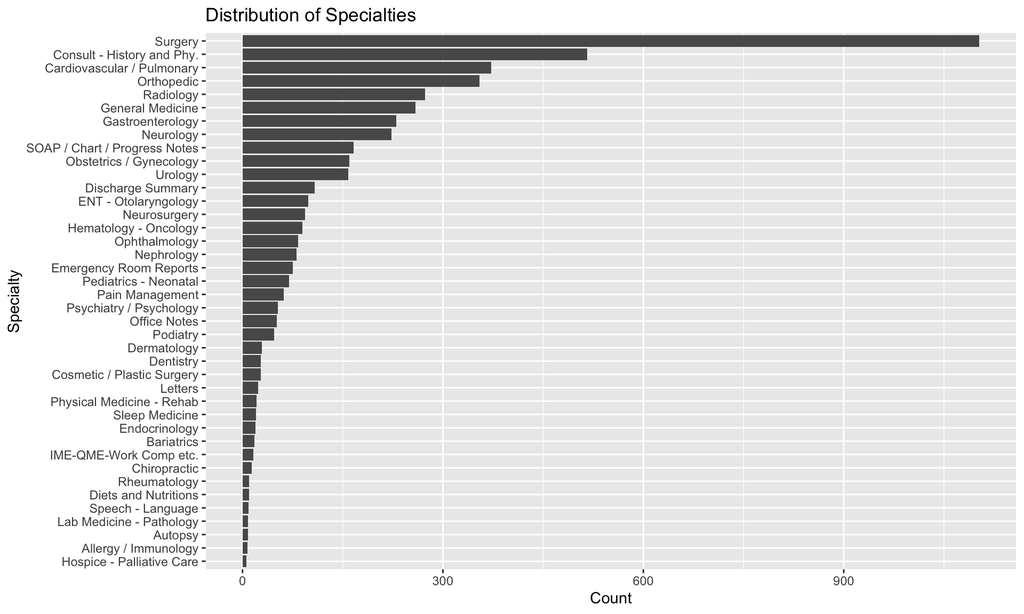

```r
# visualizing the distribution of specialties
specialty_count <- mt_samples %>%
  count(medical_specialty, sort = TRUE)

specialty_count %>%
  ggplot(aes(x = reorder(medical_specialty, n), y = n)) +
  geom_col() +
  coord_flip() +
  labs(x = "Specialty", y = "Count", title = "Distribution of Specialties")
```

The dataset comprises 40 distinct medical specialties. The distribution of occurrences among these specialties varies significantly and is not evenly distributed; “Surgery” leads the count at 1103 occurrences, while “Hospice” has the smallest count at 6 occurrences. Furthermore, there are potential overlaps and relatedness between certain specialties; for instance, Orthopedic and Radiology may both relate to the treatment and diagnosis of bone injuries.

## Question 2

- Tokenize the the words in the `transcription` column
- Count the number of times each token appears
- Visualize the top 20 most frequent words

Explain what we see from this result. Does it makes sense? What insights (if any) do we get?

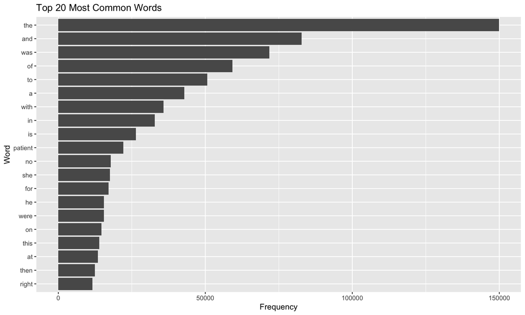

```r
# tokenizing words from the transcription column
mtsamples_tokens <- mt_samples %>%
  unnest_tokens(word, transcription)

# counting the number of times each token appears
token_count <- mtsamples_tokens %>%
  count(word, sort = TRUE)

# visualizing the top 20 most frequent words
token_count %>%
  top_n(20) %>%
  ggplot(aes(x = reorder(word, n), y = n)) +
  geom_col() +
  coord_flip() +
  labs(x = "Word", y = "Frequency", title = "Top 20 Most Common Words")
```

The analysis of the top 20 most common words from the transcription data reveals a significant prevalence of stop words, with “the” being the top word, followed by “and” and “was,” which limits the insights we can derive from this analysis. This outcome is expected, as these words serve as essential connectors and grammatical structure in English. The only potentially useful word in this context is “patient,” indicating a focus on patient-related information within the transcriptions. While the dominance of these common words is typical, it underscores the necessity of filtering out stopwords in further analysis to extract more meaningful insights related to specific medical themes or conditions.

## Question 3

- Redo visualization but remove stopwords before
- Bonus points if you remove numbers as well

What do we see know that we have removed stop words? Does it give us a better idea of what the text is about?

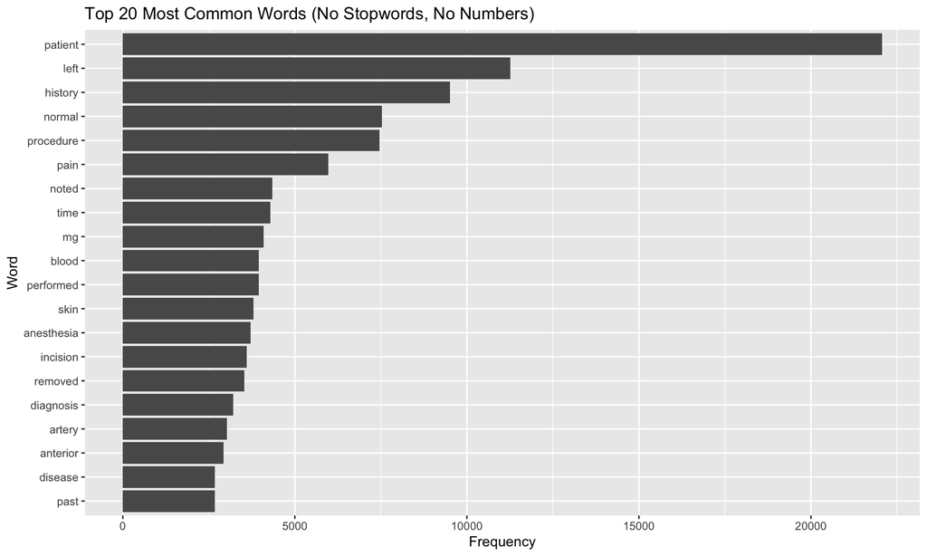

```r
# install and load stringr package
install.packages("stringr")
library(stringr)

# tokenize, remove stopwords and numbers, then count tokens again
clean_token_count <- mt_samples %>%
  unnest_tokens(word, transcription) %>%
  anti_join(stop_words, by = "word") %>%
  filter(!str_detect(word, "^[0-9]+$")) %>%
  count(word, sort = TRUE)

# visualizing the top 20 most frequent words
clean_token_count %>%
  top_n(20) %>%
  ggplot(aes(x = reorder(word, n), y = n)) +
  geom_col() +
  coord_flip() +
  labs(x = "Word", y = "Frequency", title = "Top 20 Most Common Words (No Stopwords, No Numbers)")
```

The revised visualization, which excludes stop words and numbers, presents a clearer picture of the terminology frequently used in the medical transcriptions. The most common word is “patient,” appearing over 22,000 times. Other notable terms include “left,” “history,” “normal,” and “procedure,” suggesting key aspects of patient encounters, such as their medical history, the nature of the procedures performed, and any findings related to their condition. By filtering out common stop words and numeric values, the analysis reveals a more meaningful set of terms that are likely to reflect the context and content of medical records.

# Question 4

repeat question 2, but this time tokenize into bi-grams. how does the result change if you look at tri-grams?

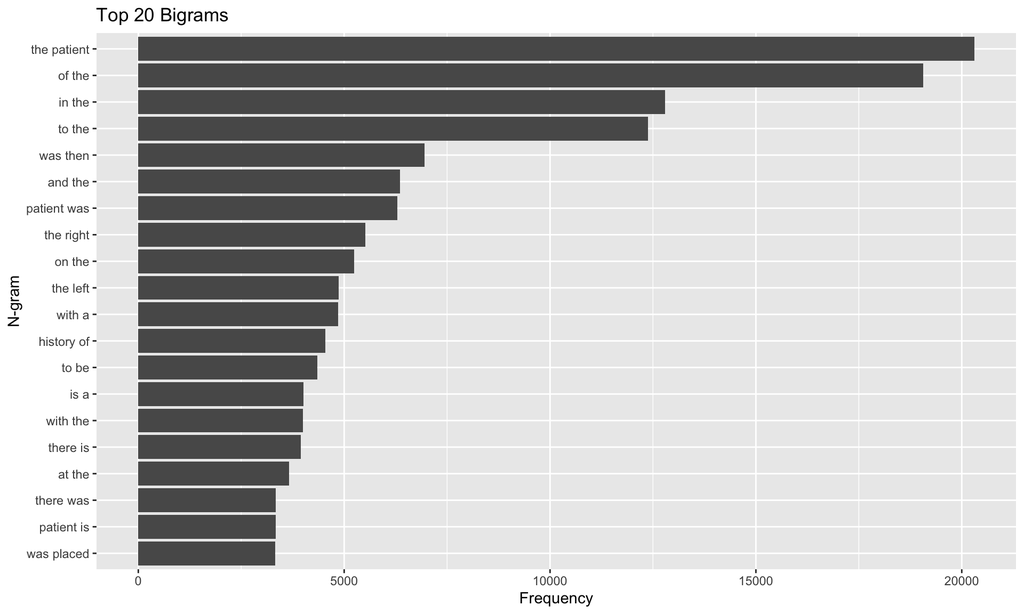

```r
install.packages("forcats")
library(forcats)

# tokenize into bigrams
mt_samples |>
  unnest_tokens(ngram, transcription, token = "ngrams", n = 2) |>
  count(ngram, sort = TRUE) |>
  top_n(20, n) |>
  ggplot(aes(n, fct_reorder(ngram, n))) +
  geom_col() +
  labs(x = "Frequency", y = "N-gram", title = "Top 20 Bigrams")
```

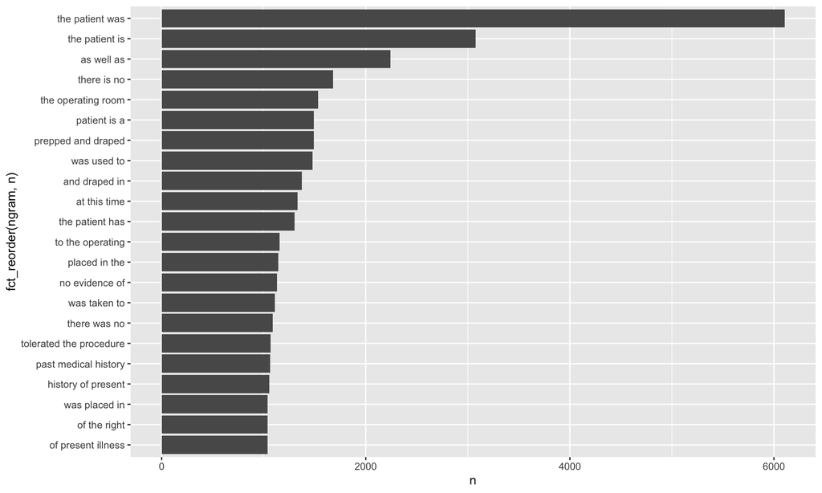

```r
# tokenize into trigrams
mt_samples |>
  unnest_tokens(ngram, transcription, token = "ngrams", n = 3) |>
  count(ngram, sort = TRUE) |>
  top_n(20, n) |>
  ggplot(aes(n, fct_reorder(ngram, n)))+
  geom_col()
```

```r
  labs(x = "Frequency", y = "N-gram", title = "Top 20 Trigrams")
```

```
$x
[1] "Frequency"

$y
[1] "N-gram"

$title
[1] "Top 20 Trigrams"

attr(,"class")
[1] "labels"
```

# Question 5

Using the results you got from questions 4. Pick a word and count the words that appears after and before it.

```r
# picking the word "surgery" and seeing what comes after it
mt_samples |>
  unnest_tokens(ngram, transcription, token = "ngrams", n = 2) |>
  separate(ngram, into = c("word1", "word2"), sep = " ") |>
  select(word1, word2) |>
  filter(word1 == "surgery") |>
  count(word2, sort = TRUE)
```

```
# A tibble: 256 × 2
   word2     n
   <chr> <int>
 1 the     170
 2 and     143
 3 in       93
 4 were     78
 5 for      76
 6 was      71
 7 she      68
 8 on       59
 9 with     48
10 he       43
# ℹ 246 more rows
```

```r
# picking the word "surgery" and seeing what comes before it
mt_samples |>
  unnest_tokens(ngram, transcription, token = "ngrams", n = 2) |>
  separate(ngram, into = c("word1", "word2"), sep = " ") |>
  select(word1, word2) |>
  filter(word2 == "surgery") |>
  count(word1, sort = TRUE)
```

```
# A tibble: 214 × 2
   word1        n
   <chr>    <int>
 1 the        220
 2 for        202
 3 of         178
 4 bypass      93
 5 with        74
 6 to          67
 7 further     60
 8 cataract    37
 9 previous    32
10 back        30
# ℹ 204 more rows
```

When looking at the words that follow “surgery,” the most common occurrences include “the” (170 times), “and” (143 times), and “in” (93 times). Conversely, when considering the words that precede “surgery,” “the” leads with 220 occurrences, followed closely by “for” (202), “of” (178), “bypass” (93), and “with” (74).

# Question 6

Which words are most used in each of the specialties. you can use `group_by()` and `top_n()` from `dplyr` to have the calculations be done within each specialty. Remember to remove stopwords. How about the most 5 used words?

```r
mt_samples |>
  unnest_tokens(words, transcription, token = "words") |>
  anti_join(stop_words, by = c("words" = "word")) |>
  group_by(medical_specialty) |>
  count(words, sort = TRUE) |>
  top_n(5, n)
```

```
# A tibble: 209 × 3
# Groups:   medical_specialty [40]
   medical_specialty          words         n
   <chr>                      <chr>     <int>
 1 Surgery                    patient    4855
 2 Surgery                    left       3263
 3 Surgery                    procedure  3243
 4 Consult - History and Phy. patient    3046
 5 Consult - History and Phy. history    2820
 6 Surgery                    0          2094
 7 Surgery                    1          2038
 8 Orthopedic                 patient    1711
 9 Cardiovascular / Pulmonary left       1550
10 Cardiovascular / Pulmonary patient    1516
# ℹ 199 more rows
```

The analysis reveals a consistent emphasis on the term “patient” across multiple specialties.

# Question 7 - extra

Find your own insight in the data:

Ideas: - Interesting ngrams - See if certain words are used more in some specialties then others

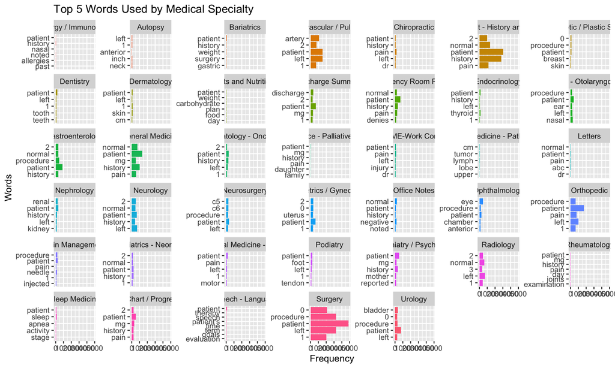

```r
# count word usage across specialties
word_specialty_counts <- mt_samples |>
  unnest_tokens(word, transcription) |>
  anti_join(stop_words, by = "word") |>
  count(medical_specialty, word, sort = TRUE) |>
  ungroup()

# visualize the top words used in each specialty
word_specialty_counts |>
  group_by(medical_specialty) |>
  top_n(5, n) |>
  ggplot(aes(fct_reorder(word, n), n, fill = medical_specialty)) +
  geom_col(show.legend = FALSE) +
  facet_wrap(~ medical_specialty, scales = "free_y") +
  labs(title = "Top 5 Words Used by Medical Specialty",
       x = "Words",
       y = "Frequency") +
  coord_flip()
```